# Analysis of Boston Restaurant Data

Sacheverel Eldrid

April 19, 2019

# Introduction

When this project was announced, I knew I wanted to do something with food. *Maybe the 11:45am - 1:25pm timeslot subconsciously affected my decision, but here we are.* After thinking it over for a few days, I decided I wanted to see if there was any corrolation between average incomes in Boston neighborhoods and the food offered there.

# Data Collection

For restaurant data, I settled on the [Yelp Fusion API](https://www.yelp.com/developers/documentation/v3). It’s incredibly intuitive to use, and only requires registering your “App” to receive an API key. This is opposed to Google Places that requires a cloud instance and a cloud account with free credits to eventually pull data that costs extra if you want pricing data which has the potential to snowball quickly. Now, the downside is for a restaurant to appear in the Yelp data, someone needs to have reviewed it. This does limit Yelp’s exposure to the newest establishments, but since the focus of this study is price trends over entire food categories I don’t think it makes a big difference in the grand scheme of things.

The other downside to Yelp, is it limits each query to a maximum result list of 1000 entries. So, if I were to try and GET all restaurants in Boston, I would only receive a list of 1000. The way this list is selected isn’t really told to us either, so we have to assume it’s some internal logic that we can’t attribute for. To get around this, I changed my query from GETting all restaurants in Boston, to individual GET requests for every zipcode in the greater Metropolitan area of Boston. Now, there still may be more than 1000 places in each of these locations but once we filtered the resulting 22000 entries for duplicates, our final Boston restaurant listhad around 4,000 entries. a firm upgrade of our original 1000 by 4 fold.

Now, with this “unique-boston-rest.csv” list we need to add a couple more columns necessary for aggregate analysis. Instead of doing this in the Python pull script, I felt it would be easier in R - so here we are re-filtering by the list of Boston area codes (in case the list of any zip included entries from outside townships), and then aggregating data per zip for a median price.

```r
#this csv file has already been filtered to remove duplicates and now includes just the ~4000 restaurants in the greater Boston Area
fixed_data <- read_csv("unique-boston-rest.csv")
temp_fixed_data <- data.frame("PriceCount" = fixed_data$PriceCount, "Zip" = fixed_data$Zip)
#filtering for only Boston zips we have income data for
temp_fixed_data <- temp_fixed_data[temp_fixed_data$Zip %in% c("2151","2152","2129","2128","2113","2114","2203","2110","2109","2108","2111","2116","2210","2199","2115","2215","2118","2127","2120","2119","2125","2122","2121","2130","2131","2126","2136","2467","2135","2134","2163"), ]
#Finds median value for Yelp price per zip code and saves them as a separate CSV for integration into QGIS
avg_column <- aggregate(. ~ temp_fixed_data$Zip, temp_fixed_data[-2], median)
median_ratings <- data.frame("Zip" = avg_column$`temp_fixed_data$Zip`, "PriceCount" = avg_column$PriceCount)
write.csv(median_ratings, "zips-and-medians.csv")
```

The data doesn’t make for a very good graphic on its own, but that’s okay. The main use for this segment is to create a new csv called “zips-and-medians.csv” that we’ll pull into QGIS as a feature column for each zip and create a heatmap. More on that below.

For income data, I used city-data.com. While they don’t have an exact trail to where *all* their data comes from, they do reference public datasets and census data as the primary sources for population and income data with the more precise fields coming from commercial sources. There’s no easy way to download the selection specific to boston area zipcodes I wanted, so this was a manual process of copying the data from their website and storing it in a csv to eventually upload into QGIS as another zipcode feature column.

The rest of our data is locations and name fields necessary for identifying the neighborhoods and zipcodes of Boston. The majority come from data.boston.gov, in the form of [zips](https://data.boston.gov/dataset/zip-codes1), [Neighborhoods](https://data.boston.gov/dataset/boston-neighborhoods), and [Colleges](https://data.boston.gov/dataset/colleges-and-universities).

## QGIS

Restaurant Pricing Map

Here is our first analysis: an overlay of median restaurant prices per zipcode over a map of Boston with neighborhood names for reference. Blue, means no data could be collected in those areas. Dark purple indicates a median restaurant price of 1 `$` (Below `$`10 for a meal), Pink is an average of 1.5 `$`, and Orange shows a median restaurant price of `$$` (Between `$`11-30).

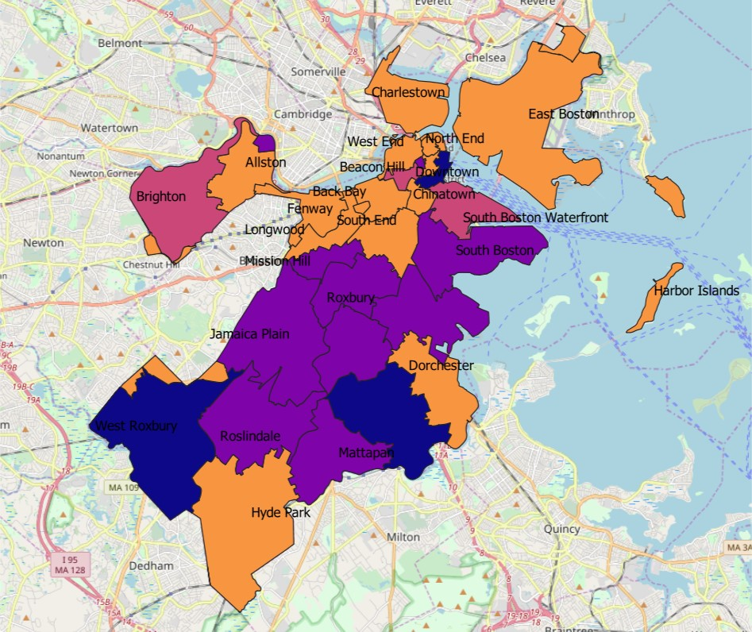

And better yet, here’s the actual key. As mentioned above, each value corrolates to how many dollar signs are associated with the price on Yelp

[figure not shown]

Map Key

Now let’s overlay the average incomes per zipcode on top. There’s going to be a lot of data here so at first it’ll look a little messy, but if you look closely…well it won’t get any cleaner but maybe by then you’ll have adjusted.

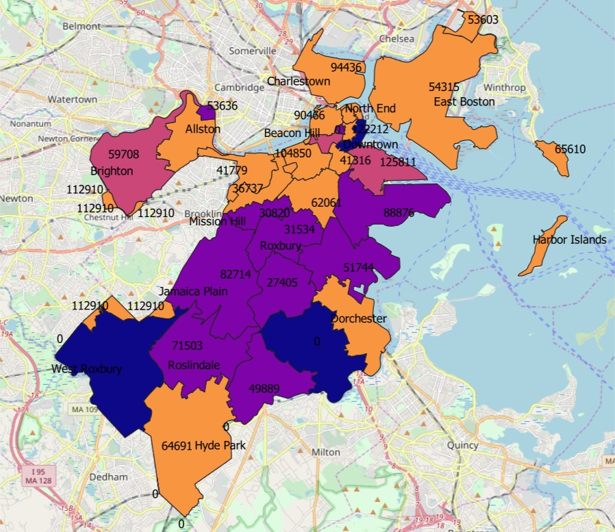

Salary Heatmap

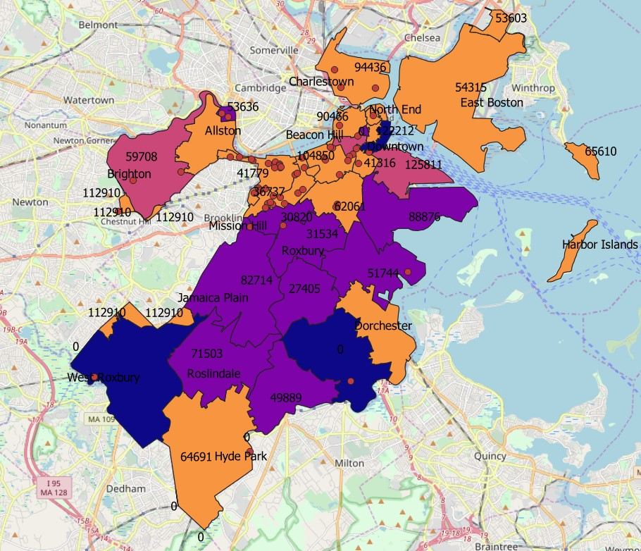

Here we’ve added red dots for all colleges and universities in the Boston area. While there are a few outliers, there’s a decided clump in the Back Bay area where restaurant prices are significantly higher than most surrounding areas. Now, as a college student I won’t say we’re the only thing contributing to higher food prices but we certainly do eat out a lot. We’ve also seen trends on and around campus specifically toward higher cost restaurants. Removing the Taco bell from Curry for a higher average cost Mediterranean eatery, and ABP leaving Marino to be replaced by Tatte. Which, funnily enough, both ABP and Tatte are owned by Panera and offer similar food options so the only *real* reason for the switch must be related to price….

## R Charts

Pricing Analysis

Apart from all the location-based data crunching, there’s also an opportunity to dig through the specific food data aggregating on type as opposed to zipcode.

First, let’s take that same unique restaurant list and create individual restaurant entries for each tag given to describe the establishment. For example, if “Amelia’s Taqueria” is tagged as both “Mexican” and “Tex-Mex”, our resulting dataset will include one entry of Amelia’s with “Mexican” as a tag, and another with “Tex-Mex”. This is the easiest way to count how many times each tag appears throughout Boston without creating incredibly complex array manipulation methods.

```r
#starting from the same data source...
fixed_data <- read_csv("unique-boston-rest.csv")
split_cats <- data.frame(row.names = fixed_data[1, ])
#creates multiple rows out of each restaurant where each row only has one food category
for(i in 1:nrow(fixed_data)) {
    row <- fixed_data[i,]
    categories <- strsplit(row$Category, ",")[[1]]
    for(j in 1:length(categories)) {
      rowTemp <- data.frame(row$Name, row$Rating, row$Price, row$PriceCount, categories[j], row$Lat, row$Long, row$City, row$Address, row$Zip)
      names(rowTemp)<-c("Name", "Rating", "Price", "PriceCount", "Category", "Lat", "Long", "City", "Address", "Zip")
      split_cats <- rbind(split_cats, rowTemp)
    }
    # do anything else we can think of
}
```

Now let’s investigate what Yelp reviewers are saying is the most pricy food in Boston. We’ll skin down the split categories data frame into just price and category before sorting, finding the mean, and filtering for all categories that have more than 5 reviews. (That way if a type of restaurant is only listed once at a value of “1”, it doesn’t completely upset the crowdsourcing angle of this data). I’m not surprised to see Steakhouses first, and organic stores not far behind.

You’ll also notice some commented-out code relating to specific zipcodes. With a few line-switches, this is the same block I did analyses for most expensive foods per Boston zipcodes, but more on that later.

```r
#split_cats
#Special code for per zip analysis
#zipped_cats <- split_cats[split_cats$Zip == 02163, ]
#skinned_cats <- data.frame("PriceCount" = zipped_cats$PriceCount, "Category" = zipped_cats$Category)
skinned_cats <- data.frame("PriceCount" = split_cats$PriceCount, "Category" = split_cats$Category)
#creates the averages column based categories
avg_column <- aggregate(. ~ skinned_cats$Category, skinned_cats[-2], mean)
freq_column <- data.frame(table(skinned_cats$Category))
freq_column <- freq_column[freq_column$Freq > 0, ]
freq_column <- data.frame("Category" = freq_column$Var1, "Count"=freq_column$Freq)
#Rename columns for easier readability
skinned_cats <- data.frame("Category" = avg_column$`skinned_cats$Category`, "AvgPrice" = avg_column$PriceCount, "Count" = freq_column$Count)
#Filter for categories with 5 or greater total entries
skinned_cats <- skinned_cats[skinned_cats$Count > 5,]
expensive_cats <- head(skinned_cats[order(skinned_cats$AvgPrice,decreasing=TRUE),], n = 20)
expensive_cats
```

```
##                   Category AvgPrice Count
## 151            Steakhouses 3.000000    17
## 214                 French 2.857143    21
## 329         Organic Stores 2.714286     7
## 227                 French 2.636364    11
## 246  Venues & Event Spaces 2.636364    11
## 93               Wine Bars 2.603175    63
## 302  Venues & Event Spaces 2.571429     7
## 108     Tapas/Small Plates 2.500000     6
## 270              Tea Rooms 2.500000     6
## 102     Tapas/Small Plates 2.421053    19
## 19             Steakhouses 2.342857    35
## 59                 Lounges 2.333333    15
## 332   Chocolatiers & Shops 2.285714     7
## 3                  Seafood 2.260000   100
## 205              Wine Bars 2.250000    12
## 46           Cocktail Bars 2.216495    97
## 163          Cocktail Bars 2.214286    14
## 45          American (New) 2.209581   167
## 39                 Lounges 2.187500    16
## 157                Spanish 2.181818    11
```

Let’s go ahead and do the same thing for cheapest food categories in Boston.

```r
#split_cats
skinned_cats <- data.frame("PriceCount" = split_cats$PriceCount, "Category" = split_cats$Category)
avg_column <- aggregate(. ~ skinned_cats$Category, skinned_cats[-2], mean)
freq_column <- data.frame(table(skinned_cats$Category))
freq_column <- data.frame("Category" = freq_column$Var1, "Count"=freq_column$Freq)
skinned_cats <- data.frame("Category" = avg_column$`skinned_cats$Category`, "AvgPrice" = avg_column$PriceCount, "Count" = freq_column$Count)
skinned_cats <- skinned_cats[skinned_cats$Count > 5,]
cheapest_cats <- head(skinned_cats[order(skinned_cats$AvgPrice,decreasing=FALSE),], n = 20)
cheapest_cats
```

```
##                  Category AvgPrice Count
## 36            Food Stands 1.000000     8
## 143           Food Stands 1.000000     6
## 204               Falafel 1.000000     8
## 146             Fast Food 1.046875    64
## 315                Donuts 1.050000    20
## 135                Bagels 1.066667    15
## 280                Kosher 1.100000    10
## 119                Donuts 1.106061    66
## 73              Fast Food 1.118280    93
## 69  International Grocery 1.133333    15
## 51           Coffee & Tea 1.156863   204
## 162           Food Trucks 1.176471    51
## 188          Chicken Shop 1.181818    11
## 5              Sandwiches 1.209150   153
## 236            Bubble Tea 1.214286    14
## 21                  Delis 1.217391    69
## 111           Food Trucks 1.222222    18
## 155                 Wraps 1.250000    16
## 180              Hot Dogs 1.307692    13
## 65                Tex-Mex 1.333333     9
```

Finding International Grocery on here is a really interesting statement about Ethnic supermarket prices, I believe Grocery was actually the highest cost food in a zip code or two…

Rating Analysis

Next, let’s take a look at the Highest rated eating establishments in Boston with a similar process to ranking by price above

```r
#In fact, the only real difference is the data frame taking Rating as opposed to PriceCount
skinned_cats <- data.frame("Rating" = split_cats$Rating, "Category" = split_cats$Category)
avg_column <- aggregate(. ~ skinned_cats$Category, skinned_cats[-2], mean)
freq_column <- data.frame(table(skinned_cats$Category))
freq_column <- data.frame("Category" = freq_column$Var1, "Count"=freq_column$Freq)
skinned_cats <- data.frame("Category" = avg_column$`skinned_cats$Category`, "Rating" = avg_column$Rating, "Count" = freq_column$Count)
skinned_cats <- skinned_cats[skinned_cats$Count > 5,]
popular_cats <- head(skinned_cats[order(skinned_cats$Rating,decreasing=TRUE),], n = 20)
popular_cats
```

```
##                    Category   Rating Count
## 194            Cheese Shops 4.444444     9
## 126          Specialty Food 4.375000    20
## 216        Fruits & Veggies 4.307692    13
## 198          Farmers Market 4.282609    23
## 297    Chocolatiers & Shops 4.272727    11
## 110         Seafood Markets 4.250000    12
## 182                 African 4.250000     6
## 152         Seafood Markets 4.222222     9
## 130              Meat Shops 4.200000    10
## 56              Pasta Shops 4.187500     8
## 42            Imported Food 4.166667     9
## 169  Food Delivery Services 4.166667     9
## 156              Meat Shops 4.153846    13
## 335            Custom Cakes 4.142857     7
## 178               Breweries 4.117647    17
## 203              Bubble Tea 4.117647    17
## 173                   Vegan 4.105263    19
## 108      Tapas/Small Plates 4.083333     6
## 326                     CSA 4.083333     6
## 82                    Greek 4.080645    31
```

Aaaaand the lowest?

```r
skinned_cats <- data.frame("Rating" = split_cats$Rating, "Category" = split_cats$Category)
avg_column <- aggregate(. ~ skinned_cats$Category, skinned_cats[-2], mean)
freq_column <- data.frame(table(skinned_cats$Category))
freq_column <- data.frame("Category" = freq_column$Var1, "Count"=freq_column$Freq)
skinned_cats <- data.frame("Category" = avg_column$`skinned_cats$Category`, "Rating" = avg_column$Rating, "Count" = freq_column$Count)
skinned_cats <- skinned_cats[skinned_cats$Count > 5,]
disliked_cats <- head(skinned_cats[order(skinned_cats$Rating,decreasing=FALSE),], n = 20)
disliked_cats
```

```
##                       Category   Rating Count
## 343                 Drugstores 2.366667    15
## 344  Cosmetics & Beauty Supply 2.409091    11
## 146                  Fast Food 2.437500    64
## 20               Chicken Wings 2.603774    53
## 188               Chicken Shop 2.727273    11
## 315                     Donuts 2.900000    20
## 119                     Donuts 3.030303    66
## 128              Chicken Wings 3.071429    21
## 73                   Fast Food 3.075269    93
## 53                     Burgers 3.078512   121
## 218         Convenience Stores 3.096774    31
## 208         Convenience Stores 3.172414    58
## 72                     Burgers 3.187500    56
## 184               Comfort Food 3.250000    12
## 34                     Chinese 3.258929   168
## 65                     Tex-Mex 3.277778     9
## 84      American (Traditional) 3.287671   146
## 51                Coffee & Tea 3.294118   204
## 81                 Sports Bars 3.333333    30
## 25                     Buffets 3.357143     7
```

There’s very few actual lowl, low reviews. So the fact that a lot of these values are so high is due to human nature not really wanting to rate a place before 2.5 stars (on average). The fact that this data is already filtered to only include restaurants actually brings more questions than answers: did people go to Drugstores expecting table service? Perhaps once they realized these are more “pay at the counter” type establishments they hit the dislike button.

## Thank You

Expensive Food Map

With that, I want to stay thanks for sticking around until the end of this document and as a reward I’ll show you my favorite restaurant graphic: most expensive foods per zipcode overlayed onto the heatmap of Boston:

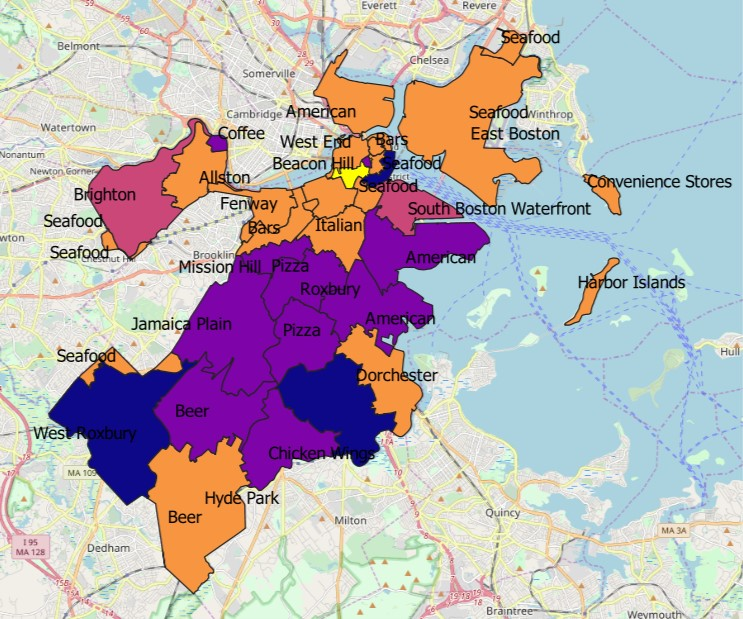

## Conclusion

I really enjoyed doing this project. While I went in with more tentative expectations for what I’d be able to accomplish, after I had pulled in the Yelp data I’ve spent the last two weeks just brainstorming any possible analysis I could think of to include. Some didn’t make the cut, but a lot were easy enough to boil down into these maps and R charts. That being said there are endless other permutations of this data I didn’t get around to but would love to explore so maybe I’ll even update this page in future! Overall, Bostonography was a fantastic course teaching me every tool to do my own analysis on city characteristics and while I didn’t necessarily prove my intiial hypothesis that average income level is directly tied to restaurant prices - I did find other factors like college locations and heaps of interesting information.

## Work Cited

As mentioned above, all of the Restaurant data comes from the Yelp Fusion API, the income data from city-data.com, and location data from data.boston.gov. For viewer convenience, here’s a list of all sources used and last access date:

- [Yelp Fusion API](https://www.yelp.com/developers/documentation/v3) *April 09, 2019*
- [City-Data](http://www.city-data.com/income/income-Boston-Massachusetts.html) *April 17, 2019*
- [Boston Zipcodes](https://data.boston.gov/dataset/zip-codes1) *April 09, 2019*
- [Boston Neighborhoods](https://data.boston.gov/dataset/boston-neighborhoods) *April 09, 2019*
- [Boston Colleges](https://data.boston.gov/dataset/colleges-and-universities) *April 10, 2019*